# Demande d’électricité en Suisse

Pierrick Vernet

2026-07-08

```r
# importer la base de données
tab<-read.csv("monthly_full_release_long_format(1).csv",na.strings = "", stringsAsFactors = FALSE,  encoding = "UTF-8")

# 1. Définition du pays cible
nom_pays <- "Switzerland"

# 2. Filtrage des données globales pour le pays choisi
df_temp <- subset(tab, Area == nom_pays)

# 3. On créer un dataframe et une time serie
demande <- subset(df_temp, Variable == "Demand", select = Value)
demandets <- ts(demande$Value, frequency = 12, start = c(2017, 1), end = c(2025, 10))

demandedf <- subset(df_temp, Variable == "Demand", select = c(Date, Value))

# 4. Conversion de la colonne Date en format Date R
demandedf$Date <- as.Date(demandedf$Date)

# 5. Vérification de l'intégrité des données
#print(paste("Nombre d'observations :", nrow(demandedf)))
#sum(is.na(demandedf$Value))

rm(tab,df_temp,demande)
```

# 1 Introduction

La Suisse figure parmi les économies les plus prospères au monde. Cette solidité financière a permis au pays d’atteindre un stade de maturité énergétique avancé. Contrairement aux économies en expansion, la Suisse évolue sur un plateau de consommation, offrant un modèle d’étude unique sur la gestion d’un système énergétique mature.

Au-delà de l’aspect économique, la Suisse se distingue par son système démocratique, où les citoyens votent régulièrement les orientations politiques. Cette trajectoire, alliant prospérité et choix souverains, constitue un point de comparaison utile pour anticiper les défis de gouvernance auxquels la France pourrait être confrontée.

Avant de passer à l’analyse statistique, il convient de décrire la situation générale du pays.

# 2 Descriptif général de l’électricité en Suisse.

## 2.1 Côté production

La production d’électricité annuelle en suisse est de 65,8 TWh pour 2022, à titre de comparaison, cela représente environ 10% de la production Française d’électricité. La production Suisse est répartie de la manière suivante :

| Source d’énergie | Part de la production |
| --- | --- |
| Nucléaire | 36,4 % |
| Hydraulique à accumulation | 28,4 % |
| Hydraulique au fil de l’eau | 24,4 % |
| Autres renouvelables | 7,7 % |
| Thermique à flamme non-renouvelable | 1,7 % |
| Thermique à flamme renouvelable | 1,4 % |
| [Source](https://fr.wikipedia.org/wiki/%C3%89lectricit%C3%A9_en_Suisse) |  |

La majorité de l’électricité en Suisse est donc produite grâce à l’énergie hydraulique des cours d’eau (52,8%), mais aussi grâce à l’énergide nucléaire (36,4%).

## 2.2 Côté consommation

La consommation annuelle d’électricité en Suisse est de 61,3 TWh pour 2022, et est répartie comme suit : (Les 4,5 TWh de différence entre la production et la consommation correspondent aux pertes réseau et au pompage (l’électricité utilisée pour remonter l’eau dans les barrages))

| Source d’énergie | Part de la consommation |
| --- | --- |
| Ménages | 34 % |
| Agriculture | 1,6 % |
| Industrie | 30,4 % |
| Services | 25,3 % |
| Transports | 8,4 % |
| [Source](https://fr.wikipedia.org/wiki/%C3%89lectricit%C3%A9_en_Suisse) |  |

En 2019, la consommation d’électricité par habitant en Suisse s’élevait à 7,35 MWh, un niveau comparable à celui de la France (7,04 MWh) et de l’Allemagne (6,6 MWh). Si cette consommation place la Suisse dans la moyenne de ses voisins directs, elle reste nettement inférieure à celle de la Norvège (23,76 MWh), tout en dépassant largement celle de pays comme la Roumanie (2,82 MWh). [Source](https://fr.wikipedia.org/wiki/%C3%89lectricit%C3%A9_en_Europe#Consommation_d'%C3%A9lectricit%C3%A9)

# 3 Chronogramme

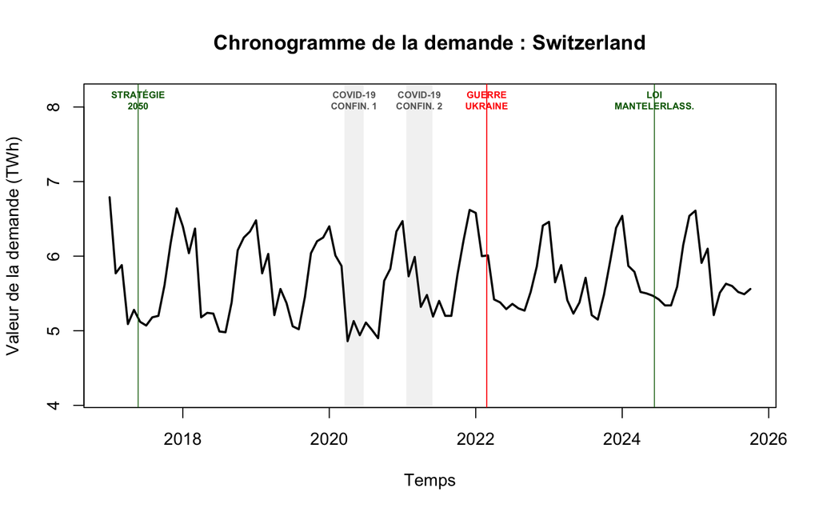

```r
# 1. Tracé du chronogramme avec le titre original
plot(demandets,
     main = paste("Chronogramme de la demande :", nom_pays),
     xlab = "Temps",
     ylab = "Valeur de la demande (TWh)",
     col = "black",
     lwd = 2,
     ylim = c(min(demandets) * 0.85, max(demandets) * 1.2)) # Marge pour les étiquettes

# 2. Ajout des zones de périodes (Confinements et Sobriété)
y_lims <- par("usr")

# Premier confinement (Printemps 2020)
rect(xleft = 2020.21, ybottom = y_lims[3], xright = 2020.47, ytop = y_lims[4],
     col = rgb(0.5, 0.5, 0.5, 0.1), border = NA)

# Deuxième confinement (Hiver 2021)
rect(xleft = 2021.05, ybottom = y_lims[3], xright = 2021.41, ytop = y_lims[4],
     col = rgb(0.5, 0.5, 0.5, 0.1), border = NA)

# 3. Ajout des lignes de repères pleines (lty = 1)
abline(v = 2017.39, col = "darkgreen", lty = 1, lwd = 0.8) # Stratégie 2050
abline(v = 2022.15, col = "red", lty = 1, lwd = 1)      # Guerre en Ukraine
abline(v = 2024.44, col = "darkgreen", lty = 1, lwd = 0.8) # Loi Électricité

# 4. Ajout des étiquettes textuelles uniformisées
y_txt <- y_lims[4]

text(x = 2017.39, y = y_txt, labels = "STRATÉGIE\n2050", pos = 1, cex = 0.55, font = 2, col = "darkgreen")
text(x = 2020.34, y = y_txt, labels = "COVID-19\nCONFIN. 1", pos = 1, cex = 0.55, font = 2, col = "gray40")
text(x = 2021.23, y = y_txt, labels = "COVID-19\nCONFIN. 2", pos = 1, cex = 0.55, font = 2, col = "gray40")
text(x = 2022.15, y = y_txt, labels = "GUERRE\nUKRAINE", pos = 1, cex = 0.55, font = 2, col = "red")
text(x = 2024.44, y = y_txt, labels = "LOI\nMANTELERLASS.", pos = 1, cex = 0.55, font = 2, col = "darkgreen")
```

## 3.1 Tendance de la série

La série ne présente pas de tendance apparente et semble fluctuer autour d’un niveau constant. Nous effectuons un test de Student pour vérifier si l’espérance du PGD est significativement différente de zéro.

- **Hypothèses :**
  $$\begin{cases} H_0 : E[X_t] = 0 \\ H_1 : E[X_t]
  \neq 0 \end{cases}$$
- **Règle de décision :**

Nous utilisons un test de Student au seuil de significativité de 5 %. La règle de décision consiste à comparer la p-value au seuil α=0,05. Si la p-value est inférieure à 0,05, nous rejetons l’hypothèse nulle.

```r
# test de student
t.test(demandets)
```

```
##
##  One Sample t-test
##
## data:  demandets
## t = 118.76, df = 105, p-value < 2.2e-16
## alternative hypothesis: true mean is not equal to 0
## 95 percent confidence interval:
##  5.582569 5.772148
## sample estimates:
## mean of x
##  5.677358
```

- **Résultats et interprétation :**

Moyenne observée : 5.677358

Statistique de test : 118.76

p-value : 2.2e-16 < 0.05

La p-value obtenue est largement inférieure au seuil de 5 %. Par conséquent, nous rejetons l’hypothèse H0, ainsi, l’espérance du PGD est différente de zéro.

## 3.2 Saisonnalité de la série

Comme la fréquence des données est mensuelle, il se peut qu’il y ait une saisonnalité. On voit d’ailleurs une forte saisonnalité, avec des pics entre 6,5 et 7 TWh durant l’hiver qui sont probablement induits par le chauffage des logements. Ainsi que des creux durant l’été aux alentours de 5 et 5,5 TWh.

## 3.3 Cluster de volatilité

La volatilité est assez régulière sur l’ensemble de la période, on peut donc conclure à une absence de cluster de volatilité.

## 3.4 Chocs et évènements géopolitiques

- **Confinements (2020-2021)** Les mesures sanitaires ont provoqué un ralentissement brutal de l’activité industrielle et commerciale. Si le télétravail a fait augmenter la consommation résidentielle, l’arrêt des secteurs tertiaire et productif a entrainé une baisse de la demande d’éléctricité qui est particulièrement visible durant le premier confinement.
- **Guerre en Ukraine (2022)** Le conflit a déclenché une crise énergétique européenne sans précédent, marquée par une envolée des prix de gros et des craintes de pénurie. En Suisse, cela aurait pu se traduire par une diminution de la demande d’éléctricté. Cependant il est difficile de voir graphiquement une différence avant/après le début de la guerre.
- [**Stratégie Énergétique 2050 (Mai 2017)**](https://www.bfe.admin.ch/bfe/fr/home/politique/strategie-energetique-2050.html/) Adoptée par votation populaire, cette stratégie vise à réduire la consommation globale via l’efficacité énergétique. Elle marque le début d’un effort national pour découpler la croissance économique de la demande d’électricité.
- **Loi sur l’électricité — Mantelerlass (Juin 2024)** Cette réforme accélère massivement l’électrification des transports et du chauffage par pompes à chaleur. Bien que l’efficacité progresse, ce jalon marque le début d’une pression à la hausse sur la demande hivernale à long terme.

# 4 Decomposition de la série

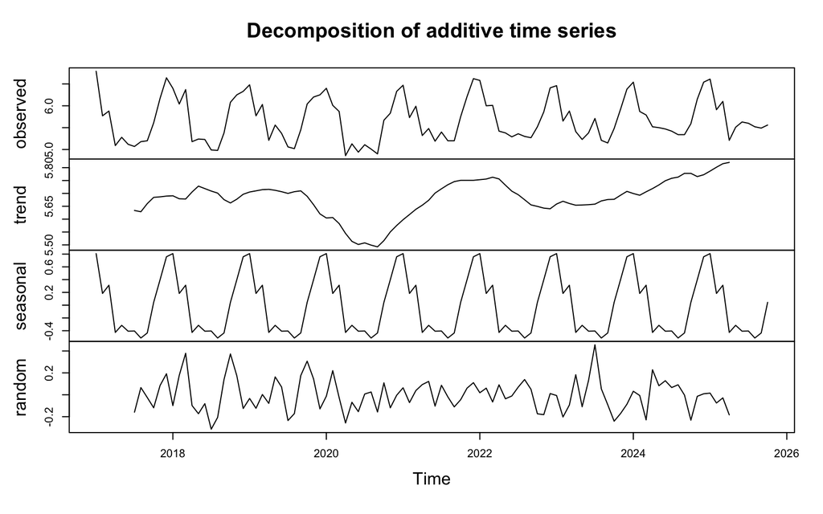

```r
plot(decompose(demandets, type = "additive"))
```

Comme l’amplitude des cycles saisonniers reste visuellement constante et que nous n’avons pas de cluster de volatilité, on réalise une décomposition additive de la série.

$$X_t = m_t + s_t + u_t$$

$$\begin{cases} X_t : \text{Observed} \\
m_t : \text{Trend} \\ s_t : \text{Seasonal} \\ u_t : \text{Random , }
E[u_t] = 0 \end{cases}$$

# 5 Monthplot

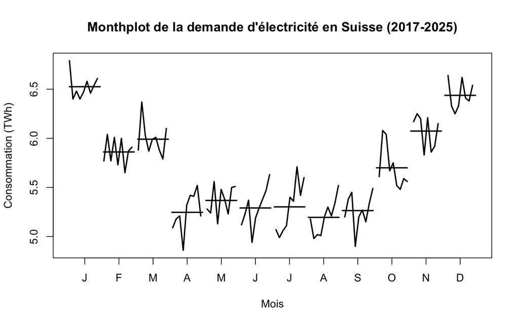

```r
monthplot(demandets,
          main = "Monthplot de la demande d'électricité en Suisse (2017-2025)",
          ylab = "Consommation (TWh)",
          xlab = "Mois",
          lwd = 2)
```

Le monthplot met en évidence une saisonnalité marquée et régulière.

La période s’étendant d’avril à septembre forme un plateau de basse consommation à environ 5,3 TWh.

À l’inverse, les mois de décembre et janvier constituent le pic de demande à environ 6,5 TWh, possiblement induit par les besoins thermiques.

L’évolution d’un mois à l’autre est progressive, marquant une transition fluide entre les régimes d’été et d’hiver, excepté pour les mois de février et mars.

La volatilité de la demande se scinde en deux régimes distincts et homogènes. La première phase, s’étendant de mars à octobre, se caractérise par une volatilité élevée mais constante.

À l’inverse, la seconde phase, allant de novembre à février, présente une volatilité faible et homogène.

# 6 Série désaisonnalisée

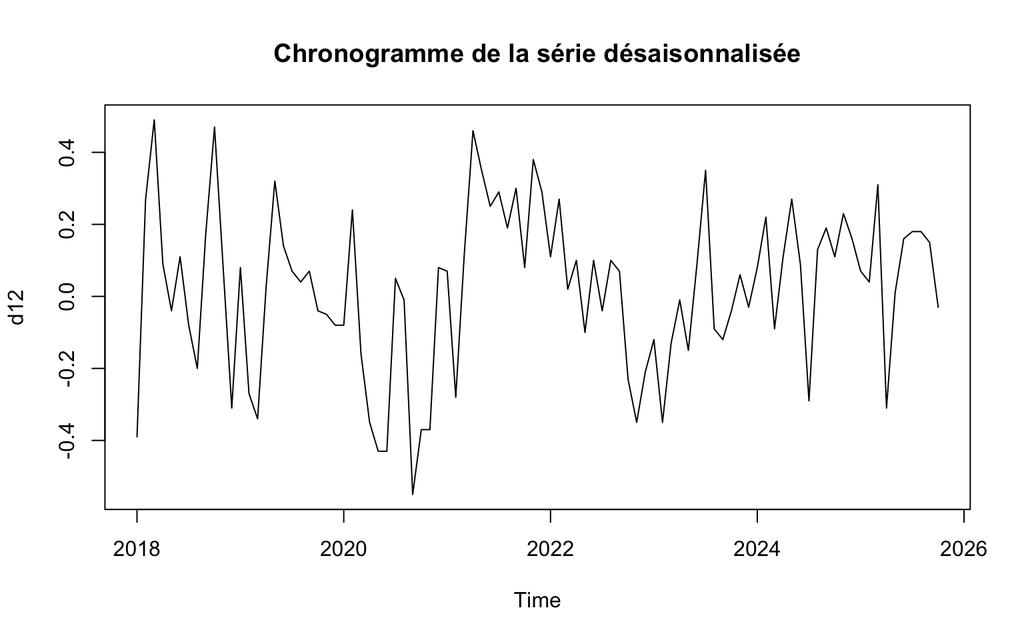

```r
# on différencie la demande à l'odrdre 12 pour la désaisonnaliser.
d12 = diff(demandets, 12)

plot(d12, main = "Chronogramme de la série désaisonnalisée")
```

Pour désaisonnaliser la série, on la différencie à l’ordre de la fréquence des données.

On différencie donc notre série à l’ordre 12, et on obtient cette nouvelle série `d12`, dont le chronogramme est affiché ci-dessus.

Nous pouvons maintenant passer aux tests de racine unitaire.

# 7 DF - Test de Dickey-Fuller

## 7.1 Spécification None

- **Équation estimée :**

$$\Delta X_t = (\rho-1) X_{t-1} +
\epsilon_t$$

- **Hypothèses :**

$$\begin{cases} H_0 : \rho -1=0 \text{
(Présence d'une racine unitaire: PGD DS)} \\ H_1 : |\rho| < 1
\text{ (Absence de racine unitaire: PGD stationnaire)}
\end{cases}$$

- **Règle de décision :**

Nous comparons la statistique de test calculée à la valeur critique de la table de Dickey-Fuller au seuil de 5 % .

Si la statistique de test est inférieur à cette valeur critiques, nous rejetons l’hypothèse nulle de non-stationnarité.

```r
summary(ur.df(d12,type = "none",lags = 0))
```

```
##
## ###############################################
## # Augmented Dickey-Fuller Test Unit Root Test #
## ###############################################
##
## Test regression none
##
##
## Call:
## lm(formula = z.diff ~ z.lag.1 - 1)
##
## Residuals:
##      Min       1Q   Median       3Q      Max
## -0.54603 -0.10473  0.01436  0.15603  0.42499
##
## Coefficients:
##         Estimate Std. Error t value Pr(>|t|)
## z.lag.1 -0.60259    0.09383  -6.422 5.81e-09 ***
## ---
## Signif. codes:  0 '***' 0.001 '**' 0.01 '*' 0.05 '.' 0.1 ' ' 1
##
## Residual standard error: 0.2038 on 92 degrees of freedom
## Multiple R-squared:  0.3095, Adjusted R-squared:  0.302
## F-statistic: 41.24 on 1 and 92 DF,  p-value: 5.815e-09
##
##
## Value of test-statistic is: -6.422
##
## Critical values for test statistics:
##      1pct  5pct 10pct
## tau1 -2.6 -1.95 -1.61
```

- **Résultats et interprétation :**

La statistique de test : -6,422

La Valeur critique (5 %) : -1,95

La statistique de test (-6,422) est inférieure à la valeur critique au seuil de 5 % (-1,95). Par conséquent, nous rejetons l’hypothèse nulle au profit de l’hypothèse alternative.

**Le PGD n’a pas de racine unitaire, il n’a pas non plus de tendance, (ni de constante). Le PGD est donc stationnaire.**

Pour que le résultat du test de Dickey-Fuller soit valide, les aléas doivent être non-autocorrelés.

On vérifie donc cette hypothèse grâce l’ACF et la PACF sur les résidus.

# 8 ACF et PACF sur les résidus

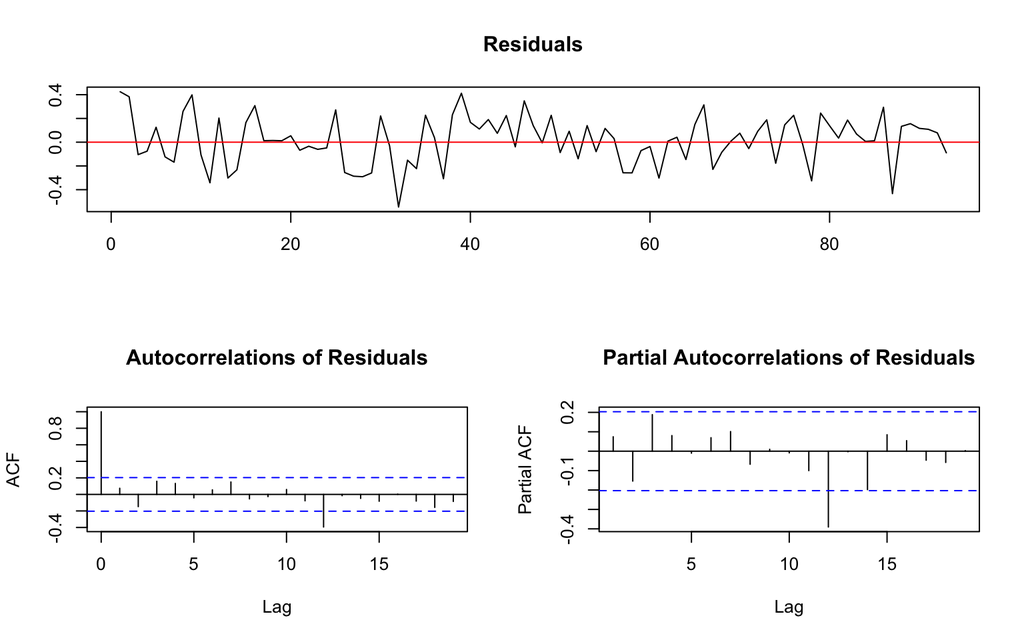

```r
plot(ur.df(d12,type = "none",lags = 0))
```

Sur les graphiques de l’ACF et de la PACF, on observe que le coefficient rho(12) est significatif au seuil de 5%, Cela signifie que les aléas à la période t ont un lien négatif avec les aléas à la période t-12.

Ainsi, les aléas sont autocorrelés, on passe donc au test de Dickey Fuller augmenté, pour prendre en compte l’effet de cette autocorrelation.

# 9 ADF - Test de Dickey-Fuller augmenté

## 9.1 Déterminer le nombre de retards

```r
# Formule de Schwert
T = length(d12)
pmax = as.integer(12 * (T / 100)^0.25)

print(paste("pmax = " , pmax))
```

```
## [1] "pmax =  11"
```

```r
summary(CADFtest(d12, criterion = "MAIC", type = "trend", max.lag.y=pmax))
```

```
## Augmented DF test
##                                               ADF test
## t-test statistic:                          -3.29672957
## p-value:                                    0.07402828
## Max lag of the diff. dependent variable:    2.00000000
##
## Call:
## dynlm(formula = formula(model), start = obs.1, end = obs.T)
##
## Residuals:
##     Min      1Q  Median      3Q     Max
## -0.4875 -0.1209  0.0193  0.1373  0.3686
##
## Coefficients:
##               Estimate Std. Error t value Pr(>|t|)
## (Intercept) -0.0304784  0.0536431  -0.568    0.572
## trnd         0.0007295  0.0009287   0.786    0.435
## L(y, 1)     -0.4418296  0.1340206  -3.297    0.074 .
## L(d(y), 1)  -0.1332100  0.1239715  -1.075    0.286
## L(d(y), 2)  -0.2257158  0.1057434  -2.135    0.036 *
## ---
## Signif. codes:  0 '***' 0.001 '**' 0.01 '*' 0.05 '.' 0.1 ' ' 1
##
## Residual standard error: 0.1922 on 77 degrees of freedom
## Multiple R-squared:  0.3333, Adjusted R-squared:  0.2987
## F-statistic: 2.281 on 2 and 77 DF,  p-value: 0.1091
```

```r
p = 2

print(paste("p = " , p))
```

```
## [1] "p =  2"
```

## 9.2 Spécification None

- **Équation estimée :**

$$\Delta X_t = (\rho-1)X_{t-1} +
\sum_{p=1}^{2} \gamma_p \Delta X_{t-p} + \epsilon_t$$

- **Hypothèses :**

$$\begin{cases} H_0 : \rho - 1 = 0 \text{
(Présence d'une racine unitaire)} \\ H_1 : |\rho| < 1 \text{
(Absence de racine unitaire)} \end{cases}$$

- **Règle de décision :**

Nous comparons la statistique de test calculée à la valeur critique de la table de Dickey-Fuller au seuil de 5 % .

Si la statistique de test est inférieur à cette valeur critique, nous rejetons l’hypothèse nulle de non-stationnarité.

```r
summary(ur.df(d12, type = "none", lags = p))
```

```
##
## ###############################################
## # Augmented Dickey-Fuller Test Unit Root Test #
## ###############################################
##
## Test regression none
##
##
## Call:
## lm(formula = z.diff ~ z.lag.1 - 1 + z.diff.lag)
##
## Residuals:
##      Min       1Q   Median       3Q      Max
## -0.46522 -0.11769  0.01902  0.15338  0.37077
##
## Coefficients:
##             Estimate Std. Error t value Pr(>|t|)
## z.lag.1     -0.45849    0.12408  -3.695 0.000381 ***
## z.diff.lag1 -0.07477    0.11331  -0.660 0.511061
## z.diff.lag2 -0.25142    0.09757  -2.577 0.011632 *
## ---
## Signif. codes:  0 '***' 0.001 '**' 0.01 '*' 0.05 '.' 0.1 ' ' 1
##
## Residual standard error: 0.1917 on 88 degrees of freedom
## Multiple R-squared:  0.3594, Adjusted R-squared:  0.3376
## F-statistic: 16.46 on 3 and 88 DF,  p-value: 1.424e-08
##
##
## Value of test-statistic is: -3.6952
##
## Critical values for test statistics:
##      1pct  5pct 10pct
## tau1 -2.6 -1.95 -1.61
```

- **Résultats et interprétation :**

Statistique de test : -3,6952

Valeur critique (5 %) : -1,95

La statistique de test (-3,695) est inférieure à la valeur critique (-1,95), donc nous rejetons H0 au seuil de 5 %.

**Le PGD n’a pas de racine unitaire, il n’a pas non plus de tendance, (ni de constante). Le PGD est donc stationnaire.**

# 10 ZA - Test de Zivot et Andrews

## 10.1 Spécification Intercept

- **L’équation estimée (Modèle Intercept) :**

Le modèle estimé avec une rupture uniquement dans le niveau et $p=2$ retards s’écrit:

$$X_{t} = \beta_{0} + \beta_{1}t + \rho
X_{t-1} + \delta_1 DU_{t}(T_{B}) + \gamma_{1}\Delta X_{t-1} +
\gamma_{2}\Delta X_{t-2} + \epsilon_{t}$$

- **Les hypothèses :**

Les hypothèses du test de Zivot-Andrews s’écrivent:

$$\begin{cases}
H_0 : \rho = 1 \text{ (PGD DS sans changement structurel)} \\
H_a : |\rho| < 1 \text{ (PGD TS avec un unique changement structurel
dans le niveau)}
\end{cases}$$

- **Règle de décision :**

Nous comparons la statistique de test calculée à la valeur critique de la table de Dickey-Fuller au seuil de 5 % .

Si la statistique de test est inférieur à cette valeur critique, nous rejetons l’hypothèse nulle de non-stationnarité.

```r
summary(ur.za(d12, model = "intercept", lag = 2))
```

```
##
## ################################
## # Zivot-Andrews Unit Root Test #
## ################################
##
##
## Call:
## lm(formula = testmat)
##
## Residuals:
##      Min       1Q   Median       3Q      Max
## -0.43729 -0.12918  0.02607  0.12872  0.39332
##
## Coefficients:
##               Estimate Std. Error t value Pr(>|t|)
## (Intercept)  0.0004385  0.0433862   0.010  0.99196
## y.l1         0.3829772  0.1373961   2.787  0.00655 **
## trend       -0.0022468  0.0014681  -1.530  0.12964
## y.dl1        0.0203810  0.1176870   0.173  0.86292
## y.dl2       -0.1835755  0.0994684  -1.846  0.06844 .
## du           0.1948329  0.0835184   2.333  0.02202 *
## ---
## Signif. codes:  0 '***' 0.001 '**' 0.01 '*' 0.05 '.' 0.1 ' ' 1
##
## Residual standard error: 0.1882 on 85 degrees of freedom
##   (3 observations deleted due to missingness)
## Multiple R-squared:  0.2874, Adjusted R-squared:  0.2455
## F-statistic: 6.858 on 5 and 85 DF,  p-value: 2.028e-05
##
##
## Teststatistic: -4.4908
## Critical values: 0.01= -5.34 0.05= -4.8 0.1= -4.58
##
## Potential break point at position: 38
```

- **Résultats et interprétation :**

Le coefficient associé à delta1 est statistiquement significatif au seuil de 5 % (p-value = 0.02202).

La spécification “intercept” est donc validée et appropriée.

On regarde maintenant si le PGD a une racine unitaire :

La statistique de test calculée est de -4.4908.

Cette valeur est supérieure à la valeur critique au seuil de 5 %, qui est de -4.8.

Par conséquent, on ne rejette pas l’hypothèse nulle.

**La série possède une racine unitaire sans changement structurel, elle est donc DS.**

# 11 LS - Test De Lee et Strazicich

Notre série différenciée comprend 94 observations, nous avons donc suffisamment d’observations pour faire un test LS sans bootstrap.

## 11.1 Test avec une unique rupture

### 11.1.1 Crash

- **Equation estimée :**

L’équation estimée par les moindres carrés ordinaires est :

$$\Delta y_{t}=\delta^{\prime}\Delta
Z_{t}+\phi\tilde{S}_{t-1}+u_{t}$$

Puisque nous testons le modèle “crash” avec une unique rupture (pour avoir une puissance plus importante), la matrice des variables exogènes $Z_{t}$ inclut une variable indicatrice uniquement pour le niveau :

$$Z_{t}= [1, tendance,
DU_{1t}]^{\prime}$$

- **Hypothèses :**

$$\begin{cases}
H_{0} : \phi = 0 \text{ (présence d'une racine unitaire, le
processus est DS avec changements structurels)} \\
H_{a} : \phi < 0 \text{ (le processus est TS avec changements
structurels)}
\end{cases}$$

- **Règle décision :**

On évalue l’hypothèse nulle à l’aide de la statistique de test associée au coefficient phi. Cette statistique doit être comparée à la valeur critique tabulée, qui dépend de la localisation estimée des deux points de rupture lambda1 et lambda2.

Si la statistique de test est inférieure à la valeur critique au seuil de 5%, on rejette H0 et on conclut que le PGD est TS avec changements structurels. Si elle est supérieure, on accepte H0.

```r
myBreaks <- 1
# Assumed break in the series, "crash" - break in intercept; "break" - break in intercept and trend
myModel <- "crash"
# Number of lags to be used in fixed specification or maximum number of lags, when using the GTOS method
myLags <- 2

ur.ls(y=d12 ,
                   model = myModel,
                   breaks = myBreaks,
                   lags = myLags,
                   method = "GTOS",pn = 0.1, print.results = "print" )
```

```
## [1] -3.932874
## [1] "First possible structural break at position: 52"
## [1] "The location of the first break - lambda_1: 0.6 , with the number of total observations: 94"
## Critical values - Crash model:
##          1%     5%    10%
## [1,] -4.239 -3.566 -3.211
## [1] "Number of lags determined by general-to-specific lag selection: 2"
## Runtime:
## Time difference of 0.0003279487 mins
```

```
## [[1]]
## [[1]]$`t-stat`
## [1] -3.932874
##
## [[1]]$`First break`
## [1] 52
##
## [[1]]$Runtime
## Time difference of 0.0003279487 mins
##
##
## [[2]]
##
## Call:
## lm(formula = y.diff ~ 0 + lagmatrix(S.tilde, 1)[, -1] + datmat[,
##     2:(slag + 2)] + Dt.diff)
##
## Residuals:
##      Min       1Q   Median       3Q      Max
## -0.53367 -0.08973  0.00000  0.12454  0.42703
##
## Coefficients: (1 not defined because of singularities)
##                                       Estimate Std. Error t value Pr(>|t|)
## lagmatrix(S.tilde, 1)[, -1]           -0.48596    0.12356  -3.933 0.000169 ***
## datmat[, 2:(slag + 2)]NoLags                NA         NA      NA       NA
## datmat[, 2:(slag + 2)]S.tilde.diff.l1 -0.05476    0.11140  -0.492 0.624258
## datmat[, 2:(slag + 2)]S.tilde.diff.l2 -0.25255    0.09788  -2.580 0.011570 *
## Dt.diff1                               0.10494    0.03401   3.086 0.002733 **
## Dt.diff2                              -0.27831    0.19229  -1.447 0.151438
## ---
## Signif. codes:  0 '***' 0.001 '**' 0.01 '*' 0.05 '.' 0.1 ' ' 1
##
## Residual standard error: 0.19 on 86 degrees of freedom
##   (3 observations deleted due to missingness)
## Multiple R-squared:  0.3853, Adjusted R-squared:  0.3495
## F-statistic: 10.78 on 5 and 86 DF,  p-value: 4.581e-08
```

Le coefficient associé à DU1t a une pvalue de :0.151438, il n’est donc pas significatif, ainsi il n’y a ni changement structurel sur la tendance ni sur le niveau.

On regarde maintenat si la série possède une racine unitaire: La statistique de test : -3.932 La valeur critique (5%) : -3.566

Comme -3.932 < -3.566, on rejette H0, la série n’a pas de racine unitaire.

**Ainsi, on rejette l’hypothèse nulle au profit de l’hypothèse alternative: La série est donc TS avec changement structurel, toutefois, le coefficient associé à la rupture structurelle sur le niveau n’est pas significatif, la série n’a donc pas de rupture structurelle.**

# 12 CONCLUSION

L’estimation du test de Dickey-Fuller aboutit au rejet de l’hypothèse nulle de racine unitaire pour la spécification “none”. Toutefois, l’analyse du corrélogramme révèle une autocorrélation des aléas, invalidant ce premier résultat. Le test de Dickey-Fuller Augmenté, paramétré avec p=2 retards pour corriger cette autocorrélation selon le critère MAIC, conclut également au rejet de l’hypothèse nulle en spécification “none”. Le processus générateur de données apparaît donc dépourvu de racine unitaire et même stationnaire.

Bien que l’ADF conclue à la stationnarité, la lecture du chronogramme laissait supposer l’existence de chocs majeurs (confinements, Guerre en ukraine). Le test de Zivot-Andrews a été mené mais n’a pas permis de rejeter l’hypothèse de racine unitaire. Cependant, ce test souffre d’un biais théorique : il présuppose l’absence de rupture sous l’hypothèse nulle, ce qui rend ses conclusions ambiguës.

Pour pallier cette limite, le test de Lee et Strazicich a été estimé en spécification “crash” et avec une rupture. Si le test rejette bien la présence d’une racine unitaire au seuil de 5%, l’analyse détaillée des coefficients révèle que le coefficient associé à la variable modélisant la rupture structurelle sur le niveau (DU1t) n’est pas statistiquement significative au seuil de 5%.

**Par conséquent, la conclusion finale retenue est celle du test de Dickey-Fuller Augmenté en spécification “none”. La demande électrique suisse désaisonnalisée suit un PGD stationnaire, sans changement structurel.**

# 13 **ANNEXE DES SPECIFICATIONS NON RETENUES**

# 14 - DF : SPECIFICATIONS NON RETENUES

Pour le test de Dickey fuller, on a testé les spécifications trend et et drift qui ne correspondaient pas, la spécification correcte etait none.

## 14.1 Spécification Trend

- **Équation estimée :**

$$\Delta X_t = (\rho-1) X_{t-1} +\beta_0 +
\beta_1 tendance_t + \epsilon_t$$

- **Hypothèses pour la spécification trend:**

Avant de tester l’hypothèse de racine unitaire, nous vérifions si la spécification trend est correct: Nous testons la significativité du coefficient beta_1:

$$\begin{cases} H_0 : \beta_1 = 0 \text{
(Absence de tendance)} \\ H_a : \beta_1 \neq 0 \text{ (Présence
d'une tendance)} \end{cases}$$

- **Règle de décision :**

Pour le coefficient Beta1, nous regardons la p-value, si elle est inférieure à 0.05, nous pouvons rejetter H0.

```r
summary(ur.df(d12,type = "trend",lags = 0))
```

```
##
## ###############################################
## # Augmented Dickey-Fuller Test Unit Root Test #
## ###############################################
##
## Test regression trend
##
##
## Call:
## lm(formula = z.diff ~ z.lag.1 + 1 + tt)
##
## Residuals:
##     Min      1Q  Median      3Q     Max
## -0.5600 -0.1102  0.0061  0.1285  0.4145
##
## Coefficients:
##               Estimate Std. Error t value Pr(>|t|)
## (Intercept)  0.0060680  0.0429510   0.141    0.888
## z.lag.1     -0.6133964  0.0955224  -6.421 6.22e-09 ***
## tt           0.0002423  0.0007975   0.304    0.762
## ---
## Signif. codes:  0 '***' 0.001 '**' 0.01 '*' 0.05 '.' 0.1 ' ' 1
##
## Residual standard error: 0.2052 on 90 degrees of freedom
## Multiple R-squared:  0.3151, Adjusted R-squared:  0.2999
## F-statistic:  20.7 on 2 and 90 DF,  p-value: 4.014e-08
##
##
## Value of test-statistic is: -6.4215 13.8122 20.7018
##
## Critical values for test statistics:
##       1pct  5pct 10pct
## tau3 -4.04 -3.45 -3.15
## phi2  6.50  4.88  4.16
## phi3  8.73  6.49  5.47
```

- **Résultat et interprétation :**

La p-value est de 0.762, on accepte donc H0. Le coefficient Beta1 n’est pas significatif au seuil de 5%. Ainsi, le PGD n’a pas de tendance.

On passe à la spécification drift :

## 14.2 Spécification Drift

- **Équation estimée :**

$$\Delta X_t = (\rho-1) X_{t-1} + \beta_0
+ \epsilon_t$$

- **Hypothèses :**

- **Règle de décision :**

Nous utilisons un test de Student. Si la p-value associée à beta0 est inférieur au seuil de 0.05, nous rejetons l’hypothèse nulle de nullité de la constante.

```r
summary(ur.df(d12,type = "drift",lags = 0))
```

```
##
## ###############################################
## # Augmented Dickey-Fuller Test Unit Root Test #
## ###############################################
##
## Test regression drift
##
##
## Call:
## lm(formula = z.diff ~ z.lag.1 + 1)
##
## Residuals:
##      Min       1Q   Median       3Q      Max
## -0.56349 -0.11840 -0.00196  0.13871  0.40464
##
## Coefficients:
##             Estimate Std. Error t value Pr(>|t|)
## (Intercept)  0.01739    0.02128   0.817    0.416
## z.lag.1     -0.61018    0.09446  -6.460 5.06e-09 ***
## ---
## Signif. codes:  0 '***' 0.001 '**' 0.01 '*' 0.05 '.' 0.1 ' ' 1
##
## Residual standard error: 0.2042 on 91 degrees of freedom
## Multiple R-squared:  0.3144, Adjusted R-squared:  0.3068
## F-statistic: 41.73 on 1 and 91 DF,  p-value: 5.064e-09
##
##
## Value of test-statistic is: -6.4597 20.8804
##
## Critical values for test statistics:
##       1pct  5pct 10pct
## tau2 -3.51 -2.89 -2.58
## phi1  6.70  4.71  3.86
```

- **Résultats et interprétation :**

La p-value est de 0.416, ce qui est supérieur à 0.05, on accepte donc H0. Le PGD n’a donc pas de constante.

On passe alors à la spécification None.

# 15 - ADF : SPECIFICATIONS NON RETENUES

Avec les test ADF, les spécifications Trend et Drift n’étaient pas adaptées.

## 15.1 Spécification Trend

- **Équation estimée :**

$$\Delta X_t = (\rho-1)X_{t-1} + \beta_0 +
\beta_1 \text{ tendance}_t + \sum_{p=1}^{2} \gamma_p \Delta X_{t-p} +
\epsilon_t$$

- **Hypothèses :**

On commence par tester si la spécification Trend est appropriée, on fait donc un test de significativité sur beta1.

$$\begin{cases} H_0 : \beta_1 = 0 \\ H_a :
\beta_1 \neq 0 \end{cases}$$

- **Règle de décision :**

Si la pvalue associée au coefficient Beta1 est inférieur à 0.05, on rejette H0.

```r
summary(ur.df(d12,type="trend", lags = p))
```

```
##
## ###############################################
## # Augmented Dickey-Fuller Test Unit Root Test #
## ###############################################
##
## Test regression trend
##
##
## Call:
## lm(formula = z.diff ~ z.lag.1 + 1 + tt + z.diff.lag)
##
## Residuals:
##      Min       1Q   Median       3Q      Max
## -0.49533 -0.11809 -0.00034  0.13990  0.39133
##
## Coefficients:
##               Estimate Std. Error t value Pr(>|t|)
## (Intercept) -0.0257922  0.0422088  -0.611 0.542770
## z.lag.1     -0.4786168  0.1270861  -3.766 0.000303 ***
## tt           0.0006871  0.0007768   0.885 0.378884
## z.diff.lag1 -0.0650727  0.1146929  -0.567 0.571945
## z.diff.lag2 -0.2429837  0.0986051  -2.464 0.015722 *
## ---
## Signif. codes:  0 '***' 0.001 '**' 0.01 '*' 0.05 '.' 0.1 ' ' 1
##
## Residual standard error: 0.193 on 86 degrees of freedom
## Multiple R-squared:  0.3656, Adjusted R-squared:  0.3361
## F-statistic: 12.39 on 4 and 86 DF,  p-value: 5.294e-08
##
##
## Value of test-statistic is: -3.7661 4.793 7.1751
##
## Critical values for test statistics:
##       1pct  5pct 10pct
## tau3 -4.04 -3.45 -3.15
## phi2  6.50  4.88  4.16
## phi3  8.73  6.49  5.47
```

- **Résultats et interprétation :**

La p-value associée à la beta1 est de 0.378884, ce qui est supérieur au seuil de 0,05.

Nous ne rejetons pas H0, et beta1 n’est pas significatif.

La spécification trend n’est pas la bonne, nous passons à la spécification drift.

## 15.2 Spécification Drift

- **Équation estimée :**

$$\Delta X_t = (\rho-1)X_{t-1} + \beta_0 +
\sum_{p=1}^{2} \gamma_p \Delta X_{t-p} + \epsilon_t$$

- **Hypothèses :**

On effectue le test sur le coefficient Beta0 pour savoir si la spécification drift est adaptée.

$$\begin{cases} H_0 : \beta_0 = 0 \\ H_a :
\beta_0 \neq 0 \end{cases}$$

- **Règle de décision :**

Si la pvalue associée au coefficient Beta0 est inférieur à 0.05, on rejette H0.

```r
summary(ur.df(d12, type="drift", lags = p))
```

```
##
## ###############################################
## # Augmented Dickey-Fuller Test Unit Root Test #
## ###############################################
##
## Test regression drift
##
##
## Call:
## lm(formula = z.diff ~ z.lag.1 + 1 + z.diff.lag)
##
## Residuals:
##      Min       1Q   Median       3Q      Max
## -0.47117 -0.12459  0.01101  0.14672  0.36384
##
## Coefficients:
##              Estimate Std. Error t value Pr(>|t|)
## (Intercept)  0.006879   0.020401   0.337 0.736786
## z.lag.1     -0.464305   0.125894  -3.688 0.000393 ***
## z.diff.lag1 -0.071366   0.114329  -0.624 0.534119
## z.diff.lag2 -0.249779   0.098182  -2.544 0.012724 *
## ---
## Signif. codes:  0 '***' 0.001 '**' 0.01 '*' 0.05 '.' 0.1 ' ' 1
##
## Residual standard error: 0.1927 on 87 degrees of freedom
## Multiple R-squared:  0.3599, Adjusted R-squared:  0.3378
## F-statistic:  16.3 on 3 and 87 DF,  p-value: 1.717e-08
##
##
## Value of test-statistic is: -3.6881 6.8153
##
## Critical values for test statistics:
##       1pct  5pct 10pct
## tau2 -3.51 -2.89 -2.58
## phi1  6.70  4.71  3.86
```

- **Résultats et interprétation :**

La p-value associée à beta0 est de 0,736, soit supérieure à 0,05.

Nous ne rejetons pas H_0, le coefficient beta0 n’est pas significatif au seuil de 5%, donc la spécification drift n’est pas adaptée. Nous passons alors à la spécification none.

# 16 - ZA : SPECIFICATIONS NON RETENUES

## 16.1 Spécification Both

- **L’équation estimée (Modèle both) :**

Pour le modèle incluant une rupture à la fois dans le niveau (intercept) et dans la pente (trend), l’équation estimée avec 2 retards s’écrit:

$$X_{t} = \beta_{0} + \beta_{1}t + \rho
X_{t-1} + \delta_{1}DU_{t}(T_{B}) + \delta_{2}DT_{t}(T_{B}) +
\gamma_{1}\Delta X_{t-1} + \gamma_{2}\Delta X_{t-2} +
\epsilon_{t}$$

- **Les hypothèses :**

$$\begin{cases}
H_0 : \rho = 1 \text{ (PGD DS sans changement structurel)} \\
H_a : |\rho| < 1 \text{ (PGD TS avec un unique changement
structurel)}
\end{cases}$$

- **Règle de décision :**

On commence par regarder si le coefficient delta2 associé à DTt est significatif, pour savoir si la spécification both est adaptée.

Si la pvalue associée à ce coefficient est inférieur à 0.05 on rejette H0, et delta2 est significatif.

```r
summary(ur.za(d12, model = "both", lag = 2))
```

```
##
## ################################
## # Zivot-Andrews Unit Root Test #
## ################################
##
##
## Call:
## lm(formula = testmat)
##
## Residuals:
##      Min       1Q   Median       3Q      Max
## -0.44808 -0.13220  0.00584  0.13180  0.37055
##
## Coefficients:
##              Estimate Std. Error t value Pr(>|t|)
## (Intercept)  0.106679   0.081177   1.314  0.19237
## y.l1         0.364102   0.135283   2.691  0.00858 **
## trend       -0.008254   0.003885  -2.124  0.03658 *
## y.dl1        0.005675   0.114021   0.050  0.96042
## y.dl2       -0.216684   0.095450  -2.270  0.02576 *
## du           0.266323   0.087796   3.033  0.00322 **
## dt           0.006991   0.004144   1.687  0.09533 .
## ---
## Signif. codes:  0 '***' 0.001 '**' 0.01 '*' 0.05 '.' 0.1 ' ' 1
##
## Residual standard error: 0.1853 on 84 degrees of freedom
##   (3 observations deleted due to missingness)
## Multiple R-squared:  0.3168, Adjusted R-squared:  0.268
## F-statistic: 6.491 on 6 and 84 DF,  p-value: 1.181e-05
##
##
## Teststatistic: -4.7005
## Critical values: 0.01= -5.57 0.05= -5.08 0.1= -4.82
##
## Potential break point at position: 35
```

- **Résultats et interprétation :**

Le coefficient associé à la rupture de tendance delta2 n’est pas significatif au seuil de 5% (p-value = 0.09533).

La spécification “both” n’est correcte que si les variables de rupture sont significatives, ainsi, cette spécification n’est pas la bonne et il faut employer la spécification “intercept”.

# 17 - LS : SPECIFICATIONS NON RETENUES

On commence par réaliser le test avec deux dates de rupture.

## 17.1 Test avec 2 ruptures

### 17.1.1 Break

- **Equation estimée :**

L’équation estimée par les moindres carrés ordinaires est :

$$\Delta y_{t}=\delta^{\prime}\Delta
Z_{t}+\phi\tilde{S}_{t-1}+u_{t}$$

Puisque nous testons le modèle “break” avec 2 ruptures , la matrice des variables exogènes $Z_{t}$ inclut des variables indicatrices pour le niveau et la pente :

$$Z_{t}= [1, tendance, DU_{1t}, DU_{2t},
DT_{1t}, DT_{2t}]^{\prime}$$

- **Hypothèses :**

$$\begin{cases}
H_{0} : \phi = 0 \text{ (présence d'une racine unitaire, le
processus est DS avec changements structurels)} \\
H_{a} : \phi < 0 \text{ (le processus est TS avec changements
structurels)}
\end{cases}$$

- **Règle décision :**

On évalue l’hypothèse nulle à l’aide de la statistique de test associée au coefficient phi. Cette statistique doit être comparée à la valeur critique tabulée, qui dépend de la localisation estimée des deux points de rupture lambda1 et lambda2.

Si la statistique de test est inférieure à la valeur critique au seuil de 5%, on rejette H0 et on conclut que le PGD est TS avec changements structurels. Si elle est supérieure, on accepte H0.

```r
myBreaks <- 2

myModel <- "break"

myLags <- 2

ur.ls(y=d12 ,
      model = myModel,
      breaks = myBreaks,
      lags = myLags,
      method = "GTOS",pn = 0.1, print.results = "print" )
```

```
## [1] -6.500743
## [1] "First possible structural break at position: 12"
## [1] "The location of the first break - lambda_1: 0.1 , with the number of total observations: 94"
## [1] "Second possible structural break at position: 38"
## [1] "The location of the second break - lambda_2: 0.4 , with the number of total observations: 94"
## Critical values:
##               Break 2 - 0.4 - 1% Break 2 - 0.4 - 5% Break 2 - 0.4 - 10%
## Break 1 - 0.2              -6.16              -5.59               -5.27
## Break 1 - 0.4                 NA                 NA                  NA
## Break 1 - 0.6                 NA                 NA                  NA
##               Break 2 - 0.6 - 1% Break 2 - 0.6 - 5% Break 2 - 0.6 - 10%
## Break 1 - 0.2              -6.41              -5.74               -5.32
## Break 1 - 0.4              -6.45              -5.67               -5.31
## Break 1 - 0.6                 NA                 NA                  NA
##               Break 2 - 0.8 - 1% Break 2 - 0.8 - 5% Break 2 - 0.8 - 10%
## Break 1 - 0.2              -6.33              -5.71               -5.33
## Break 1 - 0.4              -6.42              -5.65               -5.32
## Break 1 - 0.6              -6.32              -5.73               -5.32
## [1] "Number of lags determined by general-to-specific lag selection: 1"
## Runtime:
## Time difference of 0.01405138 mins
```

```
## [[1]]
## [[1]]$`t-stat`
## [1] -6.500743
##
## [[1]]$`First break`
## [1] 12
##
## [[1]]$`Second break`
## [1] 38
##
## [[1]]$Runtime
## Time difference of 0.01405138 mins
##
##
## [[2]]
##
## Call:
## lm(formula = y.diff ~ 0 + lagmatrix(S.tilde, 1)[, -1] + datmat[,
##     2:(slag + 2)] + DTt.diff)
##
## Residuals:
##      Min       1Q   Median       3Q      Max
## -0.44377 -0.14286  0.02339  0.11609  0.35752
##
## Coefficients: (1 not defined because of singularities)
##                                       Estimate Std. Error t value Pr(>|t|)
## lagmatrix(S.tilde, 1)[, -1]           -0.80619    0.12402  -6.501 5.21e-09 ***
## datmat[, 2:(slag + 2)]NoLags                NA         NA      NA       NA
## datmat[, 2:(slag + 2)]S.tilde.diff.l1  0.23673    0.10561   2.242 0.027592 *
## DTt.diff1                              0.32237    0.08323   3.873 0.000210 ***
## DTt.diff2                              0.49723    0.19866   2.503 0.014232 *
## DTt.diff3                             -0.33839    0.09175  -3.688 0.000397 ***
## DTt.diff4                              0.46429    0.19549   2.375 0.019801 *
## DTt.diff5                              0.03347    0.04609   0.726 0.469700
## ---
## Signif. codes:  0 '***' 0.001 '**' 0.01 '*' 0.05 '.' 0.1 ' ' 1
##
## Residual standard error: 0.1906 on 85 degrees of freedom
##   (2 observations deleted due to missingness)
## Multiple R-squared:  0.3946, Adjusted R-squared:  0.3447
## F-statistic: 7.914 on 7 and 85 DF,  p-value: 2.288e-07
```

- **Résultats et interprétation :**

On regarde donc la présence d’une racine unitaire:

La statistique de test est de -6.5.

Les lambdas estimés sont: lambda1 = 0.1 et lambda2 = 0.4 La valeur critique est de -5.59, on la trouve à l’intersection de break1 : 0.2 et Break2 : 0.4, avec alpha = 0.05.

La statistique de test est inférieur à la valeur critique : -6.5 < -5.59

Rejet de H0, la série est TS, avec 2 changements structurels sur le niveau et la tendance. Ces changements ont lieu en t = 12 et t = 38.

```r
# 1. Définition de l'indice de rupture
index_rupture <- 12

# 2. Extraction de l'année et du mois de la série
annee <- floor(time(d12)[index_rupture])
mois <- cycle(d12)[index_rupture]

# 3. Formatage de la date lisible
date_formatee <- sprintf("%02d/%d", mois, annee)
print(date_formatee)
```

```
## [1] "12/2018"
```

```r
# 1. Définition de l'indice de rupture
index_rupture <- 38

# 2. Extraction de l'année et du mois de la série
annee <- floor(time(d12)[index_rupture])
mois <- cycle(d12)[index_rupture]

# 3. Formatage de la date lisible
date_formatee <- sprintf("%02d/%d", mois, annee)
print(date_formatee)
```

```
## [1] "02/2021"
```

Les dates de rupture sont donc décembre 2018 et février 2021.

Pour avoir un test plus puissant, on fait le test LS avec une seule date de rupture.

## 17.2 Test avec 1 rupture

### 17.2.1 Break

- **Equation estimée :**

L’équation estimée par les moindres carrés ordinaires est :

$$\Delta y_{t}=\delta^{\prime}\Delta
Z_{t}+\phi\tilde{S}_{t-1}+u_{t}$$

Puisque nous testons le modèle “break” avec une unique rupture , la matrice des variables exogènes $Z_{t}$ inclut des variables indicatrices pour le niveau et la pente :

$$Z_{t}= [1, tendance, DU_{1t},
DT_{1t}]^{\prime}$$

```r
myBreaks <- 1
# Assumed break in the series, "crash" - break in intercept; "break" - break in intercept and trend
myModel <- "break"
# Number of lags to be used in fixed specification or maximum number of lags, when using the GTOS method
myLags <- 2

ur.ls(y=d12 ,
                   model = myModel,
                   breaks = myBreaks,
                   lags = myLags,
                   method = "GTOS",pn = 0.1, print.results = "print" )
```

```
## [1] -3.88526
## [1] "First possible structural break at position: 58"
## [1] "The location of the first break - lambda_1: 0.6 , with the number of total observations: 94"
## Critical values - Break model:
##      lambda    1%    5%   10%
## [1,]    0.1 -5.11 -4.50 -4.21
## [2,]    0.2 -5.07 -4.47 -4.20
## [3,]    0.3 -5.15 -4.45 -4.18
## [4,]    0.4 -5.05 -4.50 -4.18
## [5,]    0.5 -5.11 -4.51 -4.17
## [1] "Number of lags determined by general-to-specific lag selection: 2"
## Runtime:
## Time difference of 0.000549833 mins
```

```
## [[1]]
## [[1]]$`t-stat`
## [1] -3.88526
##
## [[1]]$`First break`
## [1] 58
##
## [[1]]$Runtime
## Time difference of 0.000549833 mins
##
##
## [[2]]
##
## Call:
## lm(formula = y.diff ~ 0 + lagmatrix(S.tilde, 1)[, -1] + datmat[,
##     2:(slag + 2)] + DTt.diff)
##
## Residuals:
##      Min       1Q   Median       3Q      Max
## -0.52710 -0.10641  0.00645  0.12208  0.40555
##
## Coefficients: (1 not defined because of singularities)
##                                       Estimate Std. Error t value Pr(>|t|)
## lagmatrix(S.tilde, 1)[, -1]           -0.52107    0.13412  -3.885 0.000202 ***
## datmat[, 2:(slag + 2)]NoLags                NA         NA      NA       NA
## datmat[, 2:(slag + 2)]S.tilde.diff.l1 -0.05821    0.11742  -0.496 0.621330
## datmat[, 2:(slag + 2)]S.tilde.diff.l2 -0.23329    0.09963  -2.341 0.021549 *
## DTt.diff1                              0.16236    0.05238   3.100 0.002627 **
## DTt.diff2                             -0.27080    0.19646  -1.378 0.171709
## DTt.diff3                             -0.03755    0.04474  -0.839 0.403718
## ---
## Signif. codes:  0 '***' 0.001 '**' 0.01 '*' 0.05 '.' 0.1 ' ' 1
##
## Residual standard error: 0.1916 on 85 degrees of freedom
##   (3 observations deleted due to missingness)
## Multiple R-squared:  0.382,  Adjusted R-squared:  0.3384
## F-statistic: 8.756 on 6 and 85 DF,  p-value: 1.994e-07
```

On commence par regarder si la spécification break est adaptée, on regarde donc si le coefficient associé à DT1t est significatif.

Comme sa pvalue est supérieur à 0.05, le coefficient associé à DT1t n’est pas significatif, la spécification “break” n’est pas adaptée, on passe alors à la spécification “crash”

# 18 **PARTIE 2: MODÉLISATION**

Pour rappel, notre série désaisonnalisée `d12` est stationnaire.

# 19 ACF & PACF : Identification de D.

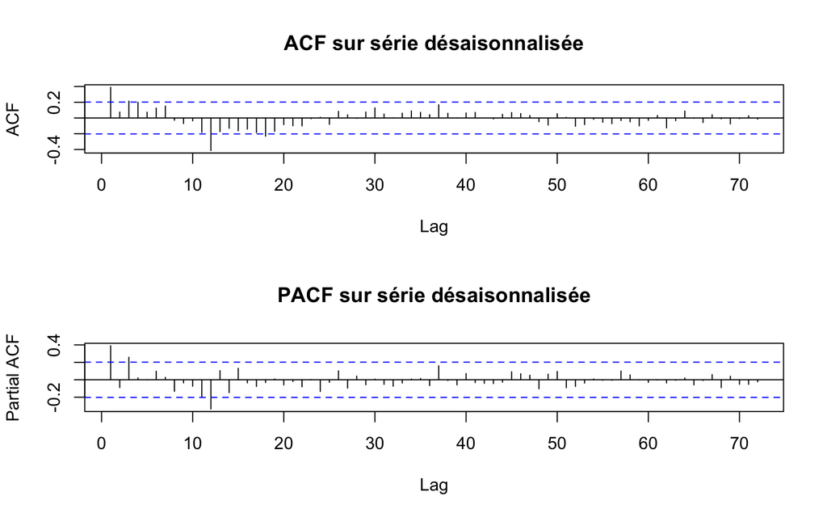

```r
op <- par(mfcol = c(2,1))
acf(as.numeric(d12),  lag.max = 12*6, main = "ACF sur série désaisonnalisée")
pacf(as.numeric(d12), lag.max = 12*6, main = "PACF sur série désaisonnalisée")
```

```r
par(op)
```

On constate que les coefficients multiples de 12 chutent rapidement vers 0, on a donc rho(24) rho(36), … qui ne sont pas significatifs, on pourra donc prendre D = 0 dans la partie saisonnière de notre modèle.

On voit que rho(12) est le dernier coefficient de corrélation significatif, dans l’ACF et dans la PACF, on peut donc essayer de modéliser un AR(12) et un MA(12).

# 20 EACF : Identification des modèles.

```r
eacf(d12)
```

```
## AR/MA
##   0 1 2 3 4 5 6 7 8 9 10 11 12 13
## 0 x o x o o o o o o o o  x  o  o
## 1 x o o o o o o o o o o  x  o  o
## 2 x x x o o o o o o o o  x  o  o
## 3 o o x o o o o o o o o  x  o  o
## 4 x o x o o o o o o o o  x  o  o
## 5 o o o o o o o o o o o  x  o  o
## 6 x x o o x o o o o o o  x  o  o
## 7 o x o x o o o o o o o  x  o  x
```

On repère le coin supérieur gauche du triangle de ‘o’ :

- En (AR=0, MA=3) : le triangle de ‘o’ est propre vers le bas et vers la droite, ce qui suggère un MA(3) sur d12, soit un SARIMA(0,0,3)(0,0,1)[12] sur la série originale.
- En (AR=1, MA=3) : la ligne AR=1 est presque entièrement composée de ‘o’ à partir de MA=2, le triangle de ‘o’ est cohérent, ce qui suggère un ARMA(1,3) sur d12, soit un SARIMA(1,0,3)(0,0,1)[12] sur la série originale.
- En (AR=2, MA=3) : le triangle de ‘o’ est également cohérent, ce qui suggère un ARMA(2,3) sur d12, soit un SARIMA(2,0,3)(0,0,1)[12] sur la série originale.

# 21 Estimation des modèles

## 21.1 Modèle 1 : SARIMA(0,0,3)(0,0,1)[12]

```r
mod1 <- Arima(demandets, order = c(0,0,3), seasonal = list(order = c(0,0,1), period = 12))
coeftest(mod1)
```

```
##
## z test of coefficients:
##
##           Estimate Std. Error z value  Pr(>|z|)
## ma1       0.586354   0.097556  6.0105 1.850e-09 ***
## ma2       0.501354   0.098239  5.1034 3.336e-07 ***
## ma3       0.291640   0.120583  2.4186   0.01558 *
## sma1      0.569091   0.082674  6.8836 5.836e-12 ***
## intercept 5.699100   0.095561 59.6382 < 2.2e-16 ***
## ---
## Signif. codes:  0 '***' 0.001 '**' 0.01 '*' 0.05 '.' 0.1 ' ' 1
```

Tous les coefficients sont significatifs, on garde le modèle comme ça.

## 21.2 Modèle 2 : SARIMA(1,0,3)(0,0,1)[12]

```r
mod2 <- Arima(demandets, order = c(1,0,3), seasonal = list(order = c(0,0,1), period = 12),fixed = c(NA, NA, NA, NA ,NA,NA))

coeftest(mod2)
```

```
##
## z test of coefficients:
##
##           Estimate Std. Error z value  Pr(>|z|)
## ar1       0.234471   0.238055  0.9849  0.324653
## ma1       0.387839   0.225675  1.7186  0.085693 .
## ma2       0.415097   0.145621  2.8505  0.004365 **
## ma3       0.220081   0.151973  1.4482  0.147573
## sma1      0.561093   0.082921  6.7666 1.319e-11 ***
## intercept 5.701532   0.105117 54.2397 < 2.2e-16 ***
## ---
## Signif. codes:  0 '***' 0.001 '**' 0.01 '*' 0.05 '.' 0.1 ' ' 1
```

Le coefficient phi1 (associé à AR(1)) est le moins significatif : on le retire.

```r
mod2 <- Arima(demandets, order = c(1,0,3), seasonal = list(order = c(0,0,1), period = 12),fixed = c(0, NA, NA, NA ,NA,NA))

coeftest(mod2)
```

```
##
## z test of coefficients:
##
##           Estimate Std. Error z value  Pr(>|z|)
## ma1       0.586351   0.097557  6.0103 1.851e-09 ***
## ma2       0.501348   0.098240  5.1033 3.338e-07 ***
## ma3       0.291623   0.120588  2.4184   0.01559 *
## sma1      0.569106   0.082673  6.8838 5.828e-12 ***
## intercept 5.699104   0.095561 59.6384 < 2.2e-16 ***
## ---
## Signif. codes:  0 '***' 0.001 '**' 0.01 '*' 0.05 '.' 0.1 ' ' 1
```

Tous les coefficients sont significatifs, on garde le modèle 2 comme ceci.

## 21.3 Modèle 3 : SARIMA(2,0,3)(0,0,1)[12]

```r
mod2 <- Arima(demandets, order = c(2,0,3), seasonal = list(order = c(0,0,1), period = 12))
coeftest(mod2)
```

```
##
## z test of coefficients:
##
##             Estimate Std. Error   z value  Pr(>|z|)
## ar1        1.7309919  0.0044981  384.8249 < 2.2e-16 ***
## ar2       -0.9983590  0.0026217 -380.8072 < 2.2e-16 ***
## ma1       -1.5195255  0.1076087  -14.1208 < 2.2e-16 ***
## ma2        0.6924579  0.1694800    4.0858 4.393e-05 ***
## ma3        0.1807627  0.0953455    1.8959   0.05798 .
## sma1       0.4556795  0.0803432    5.6717 1.414e-08 ***
## intercept  5.6912158  0.0402138  141.5238 < 2.2e-16 ***
## ---
## Signif. codes:  0 '***' 0.001 '**' 0.01 '*' 0.05 '.' 0.1 ' ' 1
```

Le coefficient associé à MA(3) (teta3) n’est pas significatif, on le retire.

```r
mod3 <- Arima(demandets, order = c(2,0,3), seasonal = list(order = c(0,0,1), period = 12), fixed = c(NA,NA,NA,NA,0,NA,NA))
coeftest(mod3)
```

```
##
## z test of coefficients:
##
##             Estimate Std. Error   z value  Pr(>|z|)
## ar1        1.7310939  0.0038058  454.8614 < 2.2e-16 ***
## ar2       -0.9984890  0.0021108 -473.0467 < 2.2e-16 ***
## ma1       -1.6965621  0.0675871  -25.1019 < 2.2e-16 ***
## ma2        0.9998175  0.0769469   12.9936 < 2.2e-16 ***
## sma1       0.4364914  0.0818641    5.3319 9.719e-08 ***
## intercept  5.6898961  0.0345761  164.5616 < 2.2e-16 ***
## ---
## Signif. codes:  0 '***' 0.001 '**' 0.01 '*' 0.05 '.' 0.1 ' ' 1
```

Tous les coefficients du modèle sont maintenant significatifs.

## 21.4 Modèle 4 : SARIMA(12,0,0)(0,0,1)[12]

```r
# AR12
mod4 <- Arima(demandets, order = c(12,0,0), seasonal = list(order = c(0,0,1), period = 12), method = "ML",
              fixed = c(NA, NA, NA, NA, NA, NA, NA, NA, NA, NA, NA, NA, NA, NA))
coeftest(mod4)
```

```
##
## z test of coefficients:
##
##             Estimate Std. Error  z value  Pr(>|z|)
## ar1        0.0771874  0.0456072   1.6924   0.09056 .
## ar2        0.0381766  0.0441521   0.8647   0.38722
## ar3       -0.0687055  0.0432978  -1.5868   0.11256
## ar4       -0.0356232  0.0448170  -0.7949   0.42670
## ar5       -0.0041485  0.0448446  -0.0925   0.92629
## ar6        0.0067025  0.0384798   0.1742   0.86172
## ar7       -0.0048931  0.0465056  -0.1052   0.91621
## ar8       -0.0613816  0.0460871  -1.3319   0.18291
## ar9       -0.0036970  0.0469550  -0.0787   0.93724
## ar10       0.0449863  0.0485227   0.9271   0.35387
## ar11      -0.0604305  0.0461104  -1.3106   0.19001
## ar12       0.8913005  0.0557461  15.9886 < 2.2e-16 ***
## sma1      -0.5811507  0.1247789  -4.6574 3.202e-06 ***
## intercept  5.6956387  0.0321329 177.2527 < 2.2e-16 ***
## ---
## Signif. codes:  0 '***' 0.001 '**' 0.01 '*' 0.05 '.' 0.1 ' ' 1
```

On retire les coefficients nons significatifs grâce à une backward selection (retirer les coefficients les moins significatifs, un par un)

```r
mod4 <- Arima(demandets, order = c(12,0,0), seasonal = list(order = c(0,0,1), period = 12), method = "ML",
              fixed = c(NA, 0, NA, 0, 0, 0, 0, NA, 0, NA, NA, NA, NA, NA))
coeftest(mod4)
```

```
##
## z test of coefficients:
##
##            Estimate Std. Error  z value  Pr(>|z|)
## ar1        0.107743   0.033157   3.2495  0.001156 **
## ar3       -0.063412   0.022482  -2.8206  0.004793 **
## ar8       -0.060758   0.024939  -2.4363  0.014839 *
## ar10       0.067226   0.022423   2.9981  0.002717 **
## ar11      -0.074662   0.033326  -2.2404  0.025066 *
## ar12       0.904169   0.023671  38.1980 < 2.2e-16 ***
## sma1      -0.564868   0.095243  -5.9308 3.014e-09 ***
## intercept  5.701242   0.042551 133.9875 < 2.2e-16 ***
## ---
## Signif. codes:  0 '***' 0.001 '**' 0.01 '*' 0.05 '.' 0.1 ' ' 1
```

## 21.5 Modèle 5 : SARIMA(0,0,12)(0,0,1)[12]

```r
#MA12

mod5 <- Arima(demandets, order = c(0,0,12), seasonal = list(order = c(0,0,1), period = 12))
coeftest(mod5)
```

```
##
## z test of coefficients:
##
##             Estimate Std. Error  z value  Pr(>|z|)
## ma1        0.4598054  0.1135710   4.0486 5.152e-05 ***
## ma2        0.2812059  0.1439434   1.9536 0.0507502 .
## ma3       -0.0143869  0.1476913  -0.0974 0.9223991
## ma4       -0.1535290  0.1450759  -1.0583 0.2899340
## ma5       -0.2717257  0.1375976  -1.9748 0.0482926 *
## ma6       -0.3741215  0.1433187  -2.6104 0.0090432 **
## ma7       -0.2660229  0.1342443  -1.9816 0.0475204 *
## ma8       -0.4241325  0.1191121  -3.5608 0.0003697 ***
## ma9       -0.3856103  0.1319834  -2.9217 0.0034817 **
## ma10      -0.0472600  0.1592781  -0.2967 0.7666849
## ma11       0.0198460  0.1995308   0.0995 0.9207705
## ma12       0.1761261  0.1360516   1.2946 0.1954741
## sma1       0.4705991  0.1080401   4.3558 1.326e-05 ***
## intercept  5.6776331  0.0094963 597.8797 < 2.2e-16 ***
## ---
## Signif. codes:  0 '***' 0.001 '**' 0.01 '*' 0.05 '.' 0.1 ' ' 1
```

On retire les coefficients non significatifs grâce à une backward selection (retirer les coefficients les moins significatifs, un par un)

```r
mod5 <- Arima(demandets, order = c(0,0,12), seasonal = list(order = c(0,0,1), period = 12),
              fixed = c(NA, NA, 0, 0, 0, 0, 0, NA, NA, 0, 0, 0, NA, NA))
coeftest(mod5)
```

```
##
## z test of coefficients:
##
##            Estimate Std. Error  z value  Pr(>|z|)
## ma1        0.542474   0.099909   5.4297 5.645e-08 ***
## ma2        0.317283   0.095215   3.3323 0.0008614 ***
## ma8       -0.359204   0.087726  -4.0946 4.229e-05 ***
## ma9       -0.350619   0.097768  -3.5862 0.0003355 ***
## sma1       0.587774   0.081520   7.2102 5.588e-13 ***
## intercept  5.688157   0.045857 124.0419 < 2.2e-16 ***
## ---
## Signif. codes:  0 '***' 0.001 '**' 0.01 '*' 0.05 '.' 0.1 ' ' 1
```

Pour valider nos modèles, nous analysons les résidus. Un bon modèle doit présenter des aléas qui sont un bruit blanc (non autocorrélés, de moyenne nulle et de variance constante) et suivant une loi normale pour pouvoir utiliser l’intervalle de confiance des prévisions. À titre d’exemple, nous présentons ici les résultats détaillés pour le Modèle 4, puis nous analyserons les résultats pour l’ensemble des modèles.

# 22 Tests des résidus des modèles

## 22.1 Test de Jarque-Bera (normalité des Aléas) :

$$\begin{align}
H_0 &: \text{les aléas suivent une loi normale} \\
H_1 &: \text{les aléas ne suivent pas une loi normale}
\end{align}$$

```r
# Récupération des résidus
res4 <- residuals(mod4)

# 1. Test de Normalité (Jarque-Bera)
# H0 : Les résidus suivent une loi normale
jarque.bera.test(res4)
```

```
##
##  Jarque Bera Test
##
## data:  res4
## X-squared = 0.010281, df = 2, p-value = 0.9949
```

Nous testons la normalité des aléas du modèle 4 afin de nous assurer de la validité des intervalles de prédiction futurs. La règle de décision stipule que si la p-value est inférieure au seuil de 5%, nous rejetons l’hypothèse nulle de normalité des aléas. Avec une p-value de 0.9949 pour le test de Jarque-Bera, nous acceptons l’hypothèse H0 et concluons que les aléas suivent une loi normale.

## 22.2 Test de Ljung-Box (autocorrélation des aléas) :

$$\begin{align}
H_0 &: \text{les aléas sont non autocorrélés} \\
H_1 &: \text{les aléas sont autocorrélés}
\end{align}$$

```r
# 2. Test de Bruit Blanc (Ljung-Box)
# H0 : Absence d'autocorrélation des résidus
# On teste sur 20 retards pour capter d'éventuels restes de saisonnalité
Box.test(res4, lag = 20, type = "Ljung-Box")
```

```
##
##  Box-Ljung test
##
## data:  res4
## X-squared = 25.186, df = 20, p-value = 0.1944
```

Nous vérifions l’indépendance des aléas par le test de Ljung-Box pour garantir qu’aucune autocorrélation n’a été oubliée par le modèle. La règle de décision consiste à rejeter l’hypothèse d’absence d’autocorrélation si la p-value est inférieure à 5%. Dans le cas du modèle 4, la p-value s’élève à 0.1944, on accepte donc H0, ainsi les aléas ne sont pas autocorrélés.

## 22.3 T-test (espérance nulle des Aléas) :

$$\begin{align}
H_0 &: \mathbb{E}({\varepsilon}_t) = 0 \\
H_1 &: \mathbb{E}({\varepsilon}_t) \neq 0
\end{align}$$

```r
# 3. Test d'Espérance Nulle (T-Test)
# H0 : La moyenne des résidus est égale à 0
t.test(res4)
```

```
##
##  One Sample t-test
##
## data:  res4
## t = 0.50087, df = 105, p-value = 0.6175
## alternative hypothesis: true mean is not equal to 0
## 95 percent confidence interval:
##  -0.02609056  0.04372698
## sample estimates:
##  mean of x
## 0.00881821
```

Le t-test est appliqué aux résidus pour vérifier que le modèle n’est pas biaisé, ce qui implique une espérance nulle des erreurs. La règle de décision indique que nous acceptons l’hypothèse d’une moyenne nulle si la p-value est strictement supérieure à 0.05. Le test affiche ici une p-value de 0.6175, nous acceptons H0 et confirmons donc que les aléas possèdent une espérance nulle.

## 22.4 Test d’Engle (homoscédasticité conditionnelle des Aléas) :

$$\begin{align}
H_0 &: \text{les aléas sont conditionnellement homoscédastiques} \\
H_1 &: \text{les aléas sont conditionnellement hétéroscédastiques}
\end{align}$$

```r
# 4. Test d'Effet ARCH (Engle-ARCH)
# H0 : Absence d'hétéroscédasticité conditionnelle (variance constante)
ArchTest(res4)
```

```
##
##  ARCH LM-test; Null hypothesis: no ARCH effects
##
## data:  res4
## Chi-squared = 9.4262, df = 12, p-value = 0.6662
```

Enfin, nous examinons l’homoscédasticité conditionnelle des résidus via le test d’Engle pour s’assurer de la stabilité de la variance dans le temps. Selon la règle de décision, une p-value supérieure au seuil alpha de 5% signifie que nous ne rejetons pas l’hypothèse d’absence d’effets ARCH. Avec une p-value de 0.6662, nous acceptons H0 et concluons que les aléas sont conditionnellement homoscédastiques.

## 22.5 Récapitulatif des Tests

```r
# --- Fonction pour extraire les p-values d'un modèle ---
get_diagnostics <- function(model, name) {
  res <- residuals(model)

  # 1. AIC & BIC
  a <- round(AIC(model), 2)
  b <- round(BIC(model), 2)

  # 2. Jarque-Bera (p-value pour la normalité)
  jb <- round(jarque.bera.test(res)$p.value, 4)

  # 3. Ljung-Box (p-value sur 20 retards pour le bruit blanc)
  lb <- round(Box.test(res, lag = 20, type = "Ljung-Box")$p.value, 4)

  # 4. T-test (p-value pour l'espérance nulle des résidus)
  ttest <- round(t.test(res)$p.value, 4)

  # 5. Engle-ARCH (p-value pour l'homoscédasticité)
  arch <- round(ArchTest(res)$p.value, 4)

  # Retourne une ligne complète du tableau
  return(data.frame(Modele = name,
                    AIC = a,
                    BIC = b,
                    Jarque_Bera = jb,
                    Ljung_Box = lb,
                    T_test = ttest,
                    Engle_ARCH = arch))
}

# --- Application aux modèles ---
tab_diag <- rbind(
  get_diagnostics(mod1, "mod1"),
  get_diagnostics(mod2, "mod2"),
  get_diagnostics(mod3, "mod3"),
  get_diagnostics(mod4, "mod4"),
  get_diagnostics(mod5, "mod5")
)

# Nettoyage des noms de lignes (évite les Chi-squared, etc.)
rownames(tab_diag) <- NULL

# --- Tableau 1 : Critères AIC et BIC ---
table_performance <- tab_diag[, c("Modele", "AIC", "BIC")]

# --- Tableau 2 : Tests de Diagnostic (p-values) ---
# Ordre : Jarque, Ljung, ttest, engle
table_tests <- tab_diag[, c("Modele", "Jarque_Bera", "Ljung_Box", "T_test", "Engle_ARCH")]

print(table_tests)
```

```
##   Modele Jarque_Bera Ljung_Box T_test Engle_ARCH
## 1   mod1      0.8562    0.0001 0.7931     0.6500
## 2   mod2      0.4586    0.0243 0.9379     0.0421
## 3   mod3      0.7424    0.0017 0.9027     0.0631
## 4   mod4      0.9949    0.1944 0.6175     0.6662
## 5   mod5      0.7038    0.0052 0.8945     0.6373
```

Pour le test de Jarque Bera, tous les modèles ont une pvalue supérieur à 5%, ainsi les aléas des 5 modèles suivent une loi normale, on peut donc utiliser l’intervalle de confiance des prédicitons avec chaque modèle.

Pour le test de Ljung-Box, on voit que seul le modèle 4 a des aléas non autocorrelés, les autres modèles sont donc à éliminer.

Pour le T-test, tous les modèles ont une pvalue supérieur à 5% et ont donc des aléas d’espérance nulle.

# 23 Performances des modèles

```r
# Affichage des résultats
print(table_performance)
```

```
##   Modele    AIC   BIC
## 1   mod1  45.60 61.58
## 2   mod2   9.15 30.46
## 3   mod3  10.46 29.11
## 4   mod4 -27.81 -3.84
## 5   mod5  35.35 54.00
```

Pour conclure sur la sélection du meilleur modèle, nous comparons les critères d’information AIC et BIC. Nous privilégions le modèle ayant les valeurs les plus faibles.

On constate immédiatement que le modèle 4 se détache nettement des autres avec un AIC de -27.81 et un BIC de -3.84, soit les seules valeurs négatives du tableau. En comparaison, les modèles 1, 2, 3 et 5 affichent des scores bien plus élevés, dépassant tous les 9 points pour l’AIC et les 29 points pour le BIC.

Le modèle 4 est donc le plus performant et le plus équilibré. Couplé aux résultats des tests sur les résidus, il s’impose comme le modèle final pour réaliser nos prévisions. Nous utiliserons donc le modèle 4 : SARIMA(12,0,0)(0,0,1)[12]